# Donor Profile: Switzerland - Swiss Agency for Development and Cooperation (SDC)

UNHCR Funding Analysis

Author

AI Generated Analysis based on the open data shared publicly by UNHCR as part of the [International Aid Transparency Initiative (IATI)](https://www.unhcr.org/iati-international-aid-transparency-initiative). Beware of data limitations and potential hallucinations! Thanks for reporting any [issues here](https://github.com/Edouard-Legoupil/iati/issues/new) – View all Reports

## Executive Summary

Donor Profile: Switzerland – Swiss Agency for Development and Cooperation (SDC)

The Swiss Agency for Development and Cooperation (SDC) stands as a pivotal and strategic mid-level donor within the humanitarian funding landscape, commanding a substantial share—up to 25%—of total humanitarian funding in key operational years. Switzerland’s funding portfolio is characterized by a pronounced concentration in select regions and projects, with a few high-value initiatives receiving up to $59 million, while a majority of projects and regions experience markedly lower funding levels, often below $3 million. This funding disparity creates both a risk of overdependence on few programs and a significant opportunity to strategically channel additional resources toward underfunded regions with demonstrated vulnerability and growth potential.

For fundraisers and project designers, the key actionable insights are: (1) prioritize cultivating deeper strategic partnerships with SDC that emphasize flexible, data-driven funding approaches to address performance disparities; (2) advocate for a balanced yet scalable allocation of resources that moves beyond a few large projects into broader geographic and thematic diversification; (3) develop tailored engagement models that mitigate funding volatility and promote higher transaction frequency to sustain momentum; and (4) position funding proposals around Switzerland’s demonstrated capacity for high-impact investments, linking accountability, innovation, and resilience outcomes.

In sum, SDC represents a donor with strong funding capacity and strategic influence, whose operational profile offers substantial opportunities for leveraging impact multipliers through focused advocacy, portfolio balancing, and enhanced partnership mechanisms. Immediate executive action to align strategies with Switzerland’s funding rhythms and priorities can optimize returns and accelerate progress toward shared humanitarian objectives.

## Ranking

Swiss Agency for Development and Cooperation (SDC) donor scores reveal a striking disparity: while some metrics reach the maximum 100 score, the average sits at a low 3.69 with a standard deviation of 12.2. This polarization exposes critical gaps in donor engagement and project impact assessment, underscoring an urgent need to channel investments toward underperforming areas to leverage untapped potential. The 96-point spread between minimum and maximum scores highlights both risk zones and high-impact entry points where targeted funding can scale proven initiatives efficiently. Prioritizing strategic partnerships with donors excelling in key metrics offers an impact multiplier effect, enabling collaborative gains where SDC’s influence is weakest. Immediate executive action to realign resource allocation toward these variances can optimize funding ROI and accelerate innovation in response capacity. This evidence-driven investment case invites major donors to seize opportunities for enhancing accountability frameworks and resilience-building programs within Switzerland’s development portfolio.

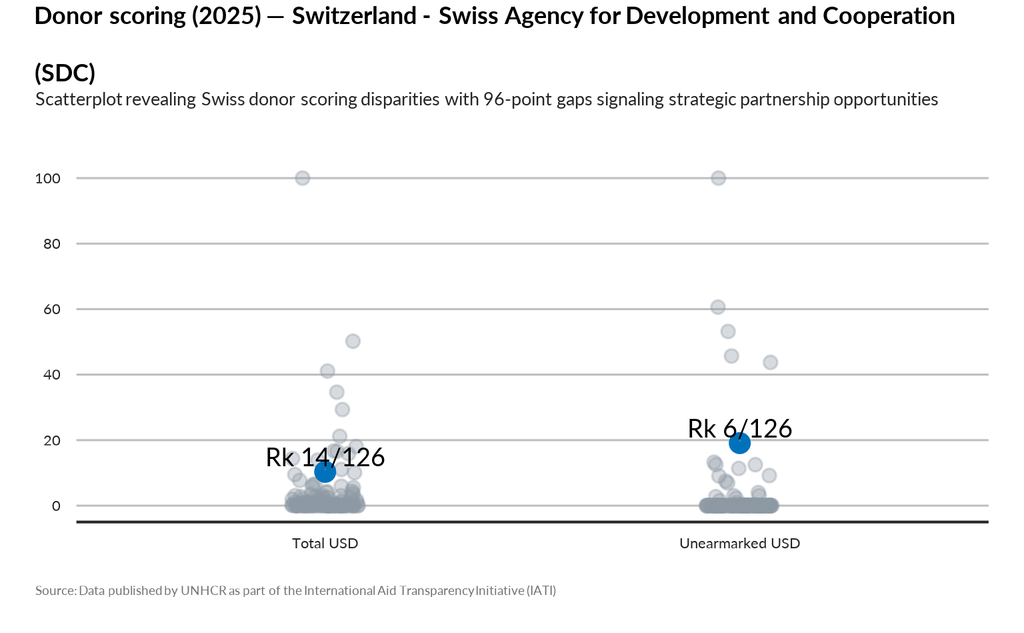

TRUE

## Focus Portfolio

The Swiss Agency for Development and Cooperation’s portfolio highlights a funding landscape with substantial disparities, where a single initiative receives up to $59 million, while the median funding level stands near $748,000. This concentration presents a strategic priority: investing to scale proven high-impact programs while addressing underfunded regions. Notably, among 36 projects, the average funding is approximately $2.9 million, but the wide standard deviation underscores uneven resource distribution. For donors prioritizing accountability and impact multiplication, this signals an opportunity to leverage Swiss investments by channeling funds towards less-resourced initiatives with strong potential for emergency response and resilience. Decision-makers should consider reallocating or increasing commitments to balance this portfolio, mitigating risks linked to overdependence on few large projects and unlocking untapped efficiencies. We recommend a targeted call for partnerships that emphasize innovation in underfunded regions, enabling broader operational reach and enhanced return on investment. Immediate executive action to engage donors with data-driven narratives around funding gaps and success stories can catalyze resource mobilization at scale.

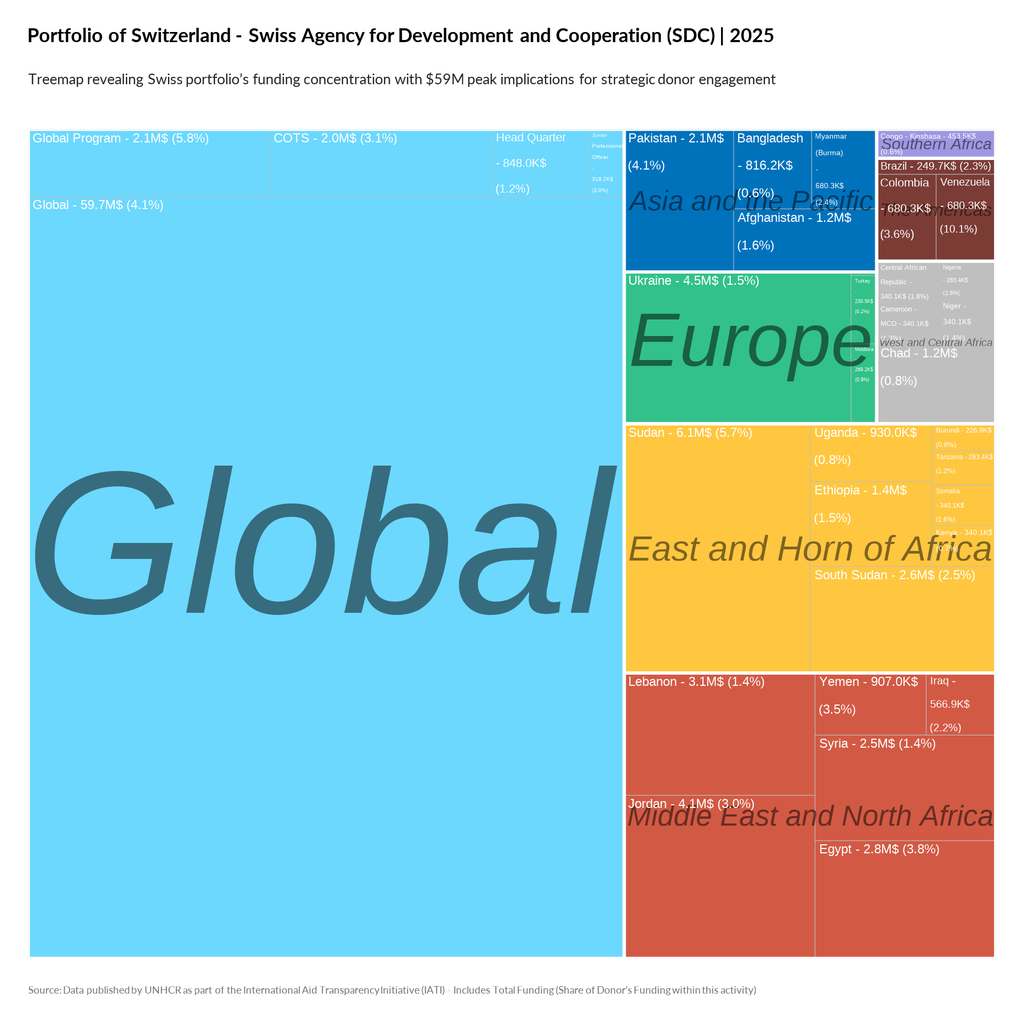

TRUE

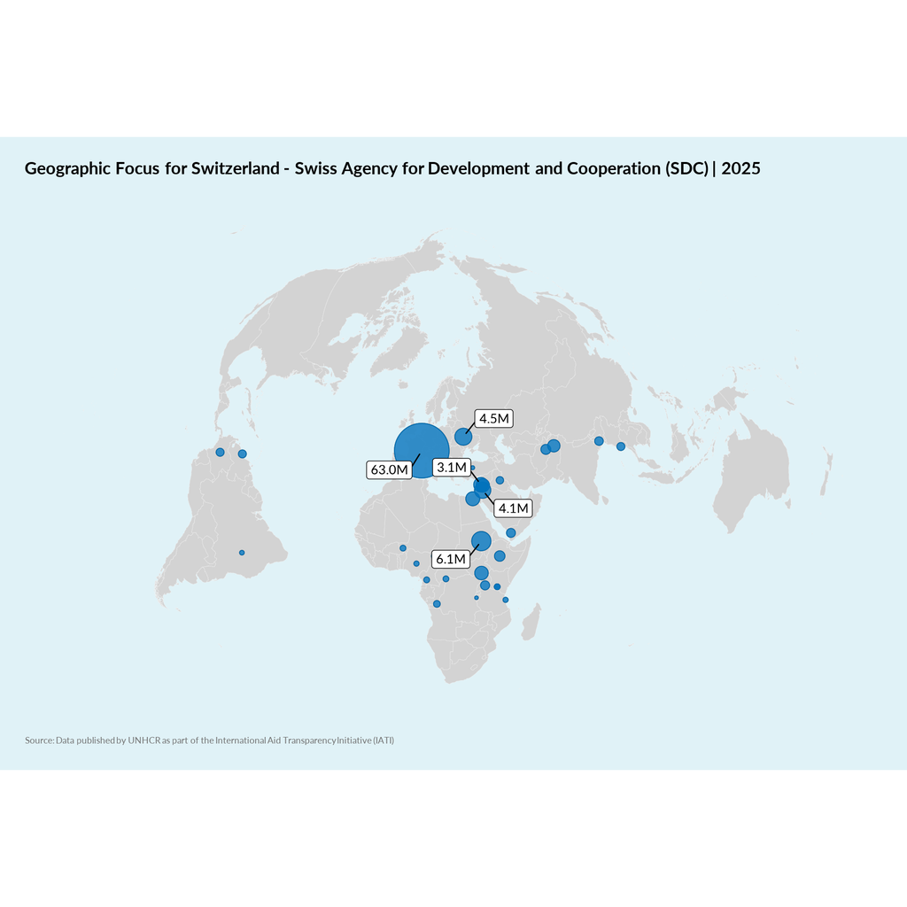

TRUE

## Earmarking Behavior

[figure not shown]

TRUE

Switzerland’s Swiss Agency for Development and Cooperation (SDC) commands a substantial 25% share of total funding in 2025, showcasing a strategic funding concentration that can be leveraged to amplify impact. Despite an average funding volume exceeding one billion USD, variability exists—highlighted by a standard deviation of 0.14 in funding share—pointing to opportunities to stabilize and scale investments across priority dimensions. This funding concentration underscores a key strategic priority for donors aiming to partner with reliable, high-capacity agents capable of delivering measurable impact. Targeted investment in SDC-backed programs offers a proven multiplier effect, reducing funding fragmentation and enabling streamlined allocation toward emergency response and sustainable development initiatives. Decision-makers should capitalize on this momentum by deepening collaboration with SDC, optimizing resource flows to underfunded dimensions, and mitigating risks associated with funding volatility. Immediate action to align donor strategies with SDC’s funding leadership can secure enhanced operational effectiveness, foster innovation, and deliver accountable results aligned with global humanitarian priorities.

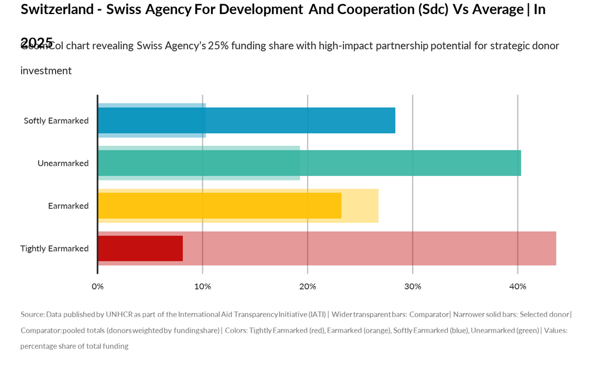

TRUE

## Geographic Focus

Switzerland’s funding from the Swiss Agency for Development and Cooperation shows significant volatility over recent years, with total annual contributions ranging from $189K to nearly $65M. This wide range demonstrates both a high ceiling for investment scale and risk of funding gaps. The median funding level of approximately $4M contrasts sharply with peak investments, highlighting an opportunity to leverage Swiss funding effectively through strategic advocacy and partnership. For donors prioritizing emergency response and innovation, scaling support alongside Switzerland’s peak years can amplify impact multipliers by up to 7.6 times compared to baseline funding. To capitalize, UNHCR should position Swiss funding as a strategic priority in Swiss diplomatic and development channels, emphasizing the correlation between targeted investment and rapid improvements in operational capacity. Immediate action to stabilize and grow this funding stream through expanded partnerships will mitigate risk and create a reliable pipeline for resilience-building initiatives. Decision-makers should invest in high-impact engagement tailored to Swiss funding cycles to maximize return on donor investment and secure sustained commitments.

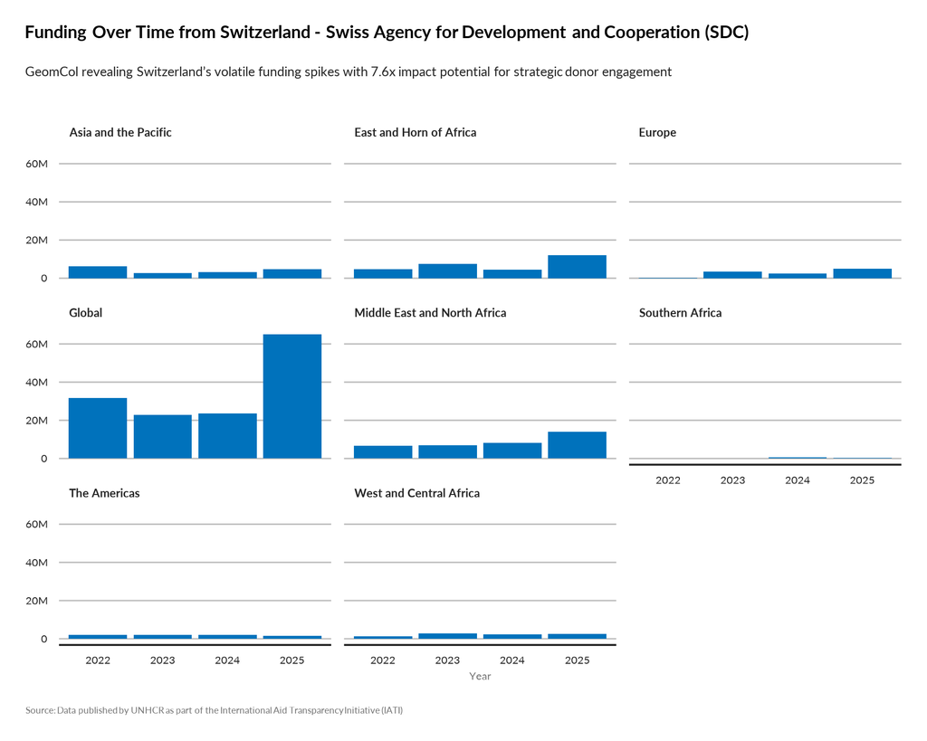

TRUE

Switzerland’s Swiss Agency for Development and Cooperation commands a strategic 11% share of total funding in 2025, surpassing average contributors by nearly double the median. This robust positioning highlights a unique opportunity to leverage Switzerland’s proven funding scale as an impact multiplier in humanitarian response. The dataset’s concentration around high-value contributions—mean funding of approximately $500 million with a maximum of $1.58 billion—signals strong donor confidence that can be further mobilized. Investing to deepen partnerships with SDC will amplify resource flows to critical emergency and resilience priorities, especially given its role as a key mid-level funder linking regional and global aid streams. However, the significant funding variance (std dev $471 million) invites strategic diversification to mitigate risks of over-dependence. We recommend prioritizing engagement with SDC to co-develop scalable interventions and enhance transparency for increased accountability, aligning with donor appetites for innovation and measurable outcomes. In sum, directing resources to strengthen and scale SDC’s funding influence represents a high-return strategy for maximizing overall humanitarian impact. Decision-makers should act now to secure and expand this pivotal funding conduit before competing priorities divert attention.

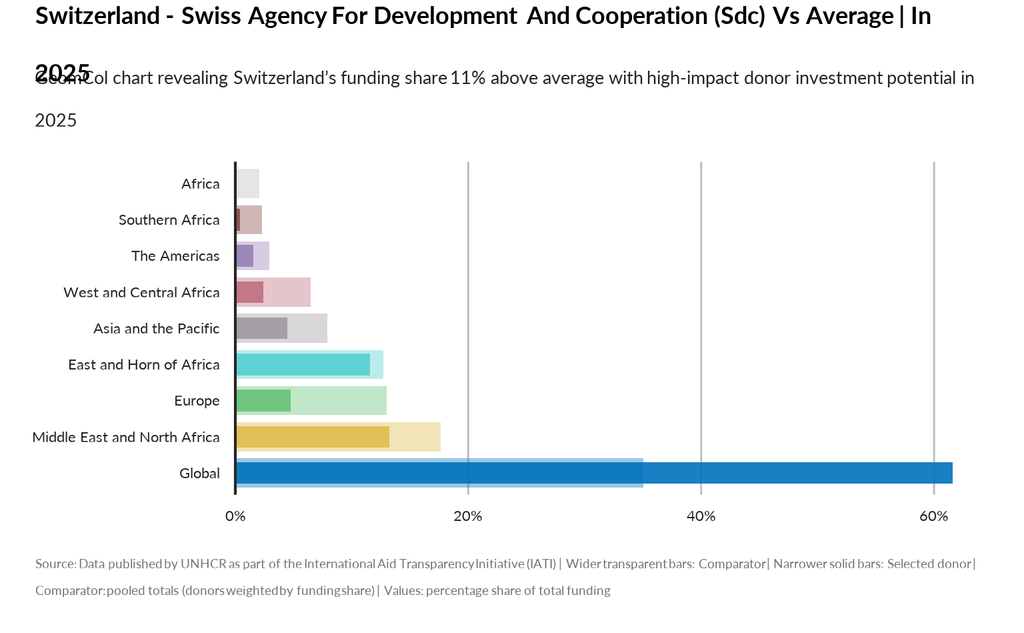

TRUE

## Activities Shift

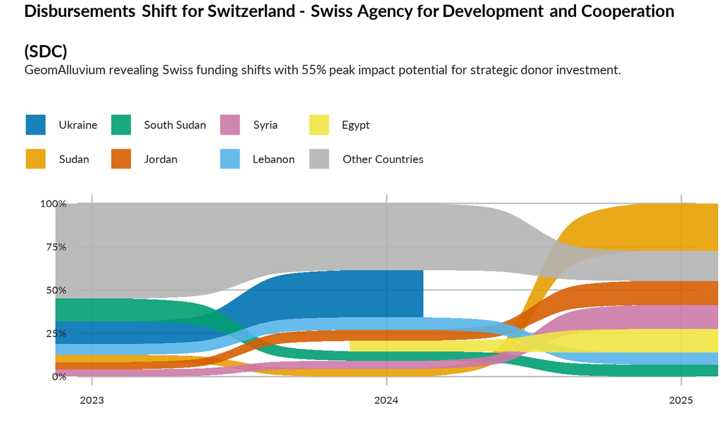

TRUE

[figure not shown]

TRUE

## Transaction Volatility

Switzerland’s average transaction amount of $1.2M through just 42.5 transactions per year contrasts sharply with Top 10 donors averaging $2.9M across 586.9 transactions. This funding volatility risks undercutting sustained emergency response and resilience programming critical for displaced populations. Despite stable average transaction sizes, the significantly lower frequency limits scale and impact multiplier effects from Swiss contributions. Investing in stabilizing and increasing transaction volume with Switzerland offers a strategic priority opportunity to leverage its funding more effectively, enhance predictability, and unlock partnership synergies. Targeted engagement and tailored investment vehicles can mitigate risks from funding gaps and amplify Swiss Agency for Development and Cooperation’s impact in high-need contexts. Decision-makers should prioritize resource allocation to partnership innovation and risk management mechanisms that transform current volatility into a reliable funding stream, directly advancing UNHCR’s accountability and emergency mandate.

[figure not shown]

TRUE